# Investigating the Impact of Student-Teacher Ratio on Literacy Rates: A Multifaceted Analysis

## Introduction

Education is fundamental to societal progress, with literacy rates being a key indicator of a society's educational health. This study investigates the relationship between the student-teacher ratio and literacy rates among adults. The student-teacher ratio is a critical indicator of educational quality, with lower ratios potentially leading to higher literacy due to more individualized attention.

This analysis extends beyond the student-teacher ratio to include factors like government expenditure on education, GDP per capita,primary education completion rate, and average years of schooling. These variables are considered to unravel the specific impact of student-teacher ratios from the broader socio-economic context.

The goal is to determine the extent to which the student-teacher ratio, among these factors, influences literacy rates.

## Data

The dataset initially comprised 47 indicators across 272 countries or regions, spanning 20 years, resulting in a total of 12,784 rows. The indicators encompass a range of educational, and economic metrics. To address the challenge of numerous missing values in yearly data, we calculated the average of each indicator across the 20-year period for each country. This approach not only mitigated the issue of missing data but also provided a more consolidated and long-term perspective of each indicator at the country level.

For our analysis, we've selected key indicators from the World Bank data, grouped into two main categories:

**Educational Indicators:**

- Literacy Rate, Population 25-64 Years, Both Sexes (%): Reflects the adult literacy level, essential for understanding everyday life.
- Student-Teacher Ratio in Primary Education: Indicates the average number of students per teacher, a proxy for educational quality.
- Completion Rate, Primary Education, Both Sexes (%): Measures the effectiveness of primary education systems in retaining students.
- Average Years of Total Schooling, Age 25+, Total: Represents the average educational attainment of the adult population.

**Economic Indicators:**

- Government Expenditure on Education as % of GDP: Shows the government's financial commitment to education relative to the country's overall economic output.
- GDP per Capita (current US$): A key measure of economic performance and standard of living.

These indicators collectively provide insights into the relationship between student-teacher ratio, economic conditions, and educational outcomes, particularly literacy rates. The educational indicators focus on the quality and effectiveness of education systems, while the economic indicators reflect national priorities and capabilities concerning education.

|  | avg_ed_years | prim_comp_rate | gdp_capita | gdp_capita_ppp | gov_exp | lit_rate | stu_teach_ratio |
| --- | --- | --- | --- | --- | --- | --- | --- |
| count | 61.000000 | 61.000000 | 61.000000 | 61.000000 | 61.000000 | 61.000000 | 61.000000 |
| mean | 6.132623 | 76.386557 | 4256.105246 | 8622.676557 | 4.022459 | 75.356393 | 34.117049 |
| std | 2.803604 | 22.480215 | 8872.239448 | 14981.295774 | 1.603432 | 22.886058 | 20.379016 |
| min | 1.180000 | 22.600000 | 230.060000 | 707.020000 | 1.350000 | 26.810000 | 11.340000 |
| 25% | 3.810000 | 61.750000 | 783.090000 | 2329.790000 | 3.020000 | 59.120000 | 21.540000 |
| 50% | 6.160000 | 83.840000 | 2239.150000 | 6063.530000 | 3.870000 | 78.790000 | 27.970000 |
| 75% | 8.020000 | 96.950000 | 4735.060000 | 9977.220000 | 4.780000 | 94.920000 | 43.560000 |
| max | 11.580000 | 99.710000 | 67461.320000 | 116342.470000 | 10.250000 | 99.980000 | 135.610000 |

## Analysis

We will construct several models to investigate the true correlation between the student-teacher ratio and literacy rates, examining how other educational and economic factors may influence this relationship. Our first and third models will employ single linear regression, focusing exclusively on these two variables. Subsequent models will incorporate multiple regressions with various "control variables" representing relevant educational and economic indicators. This multi-model strategy will allow for a more nuanced understanding of the underlying dynamics.

First, we will create a scatter plot to visualize the relationship between the student-teacher ratio and literacy rates.

[figure not shown]

The plot (Fig. 1) reveals a negative correlation between the two variables, suggesting that an increase in the number of students per teacher could lead to a decrease in literacy rates. This may be because a teacher's capacity to effectively educate is limited by the number of students they must attend to.

In all our models standard errors are calculated using the Heteroskedasticity-Consistent (HC1) method. Heteroskedasticity occurs when the variance of the errors is not constant across all levels of the independent variable(s). The HC1 method adjusts for this by providing robust standard errors that are more reliable in the presence of heteroskedasticity.

### Model 1

**Level-level**: $({literacy\_rate})^E = \alpha + \beta \times {student\_teacher\_ratio}$

In the linear regression model examining the relationship between `student-teacher ratio` and `literacy rates` (check **Appendix 1** first column), the intercept is found to be 98.761. This value represents the expected literacy rate when the student-teacher ratio is zero. While this scenario is hypothetical and not practically feasible, the high value of the intercept suggests a baseline literacy rate in an ideal educational setting with extremely low student-to-teacher ratios. The model's coefficient for the student-teacher ratio is -0.686, indicating that for each additional student per teacher, the literacy rate is expected to decrease by about 0.686 units (in our case percentages). This finding underscores the potential negative impact of higher student-teacher ratios on literacy rates.

Both the intercept and the coefficient of the student-teacher ratio are **statistically significant at 1%**, as evidenced by their p-values and confidence intervals. The p-values are sufficiently low to reject the null hypothesis that the coefficients are equal to zero, indicating a statistically significant relationship between student-teacher ratio and the literacy rate. Additionally, the confidence intervals for these coefficients do not include zero, further supporting their significance. The model's R-squared value of 0.373 implies that around 37.3% of the variation in literacy rates is explained by the student-teacher ratio, pointing to a moderate explanatory power but also suggesting the presence of other influential factors not included in the model. While the statistical analysis provides significant insights, it is important to interpret these results within the broader context of educational research, considering other variables that might also play a role in determining literacy rates.

### Model 2

**Level-level**:  
$({literacy\_rate})^E = \alpha + \beta_1 \times {student\_teacher\_ratio} + \beta_2 \times {gov\_exp}$

In the second model of our analysis, which includes both the student-teacher ratio and government expenditure on education as predictors of literacy rates (check **Appendix 1** second column), we observe some intriguing results. The model shows an R-squared value of 0.39, suggesting that about 39% of the variation in literacy rates can be explained by these two variables combined. This marks a slight improvement in explanatory power compared to the first model, which only included the student-teacher ratio.

The intercept in this model is 91.14 (signifant at 1%), which theoretically represents the expected literacy rate when both the student-teacher ratio and government expenditure on education are zero. Practically, this is an abstract baseline, as it's not feasible to have these conditions in reality. However, it does give us a starting point for understanding the model's predictions.

The coefficient for the student-teacher ratio (signifant at 1%) remains negative (-0.68) and is quite similar to that in the first model, reaffirming the inverse relationship between the student-teacher ratio and literacy rates. Interpretation is the same as in the first model (we just mention that other variables should remain constant). The consistency of this coefficient across both models strengthens the argument that higher student-teacher ratios, potentially indicative of less individual attention in classrooms, are associated with lower literacy rates.

The coefficient for government expenditure on education is 1.82, suggesting a positive relationship with literacy rates. However, its p-value of 0.08 indicates that this relationship is not statistically significant at conventional levels (like 0.05 or 0.01 that we accept for this study). This implies that while there seems to be a positive trend between government expenditure on education and literacy rates, we cannot confidently assert this as a statistically significant finding based on this model.

The confidence intervals for the student-teacher ratio exclude zero, allowing us to reject the null hypothesis that its coefficient is zero and affirm its significance in the model. However, for government expenditure, the confidence interval includes zero, reflecting its statistical insignificance in this context.

Overall, the second model suggests a nuanced view where the student-teacher ratio continues to play a significant role in literacy rates, while the impact of government expenditure on education, although positive, lacks statistical certainty. As with any regression analysis, these findings should be interpreted in the context of the broader socio-economic and educational landscape, and they highlight the complexity of factors influencing literacy.

Our analysis aims to unravel the underlying dynamics, and even non-significant variables can yield insights. Thus, we have decided to retain non-significant variables in our model for their potential explanatory value.

Before constructing Model 3, which uses the natural logarithm of the student-teacher ratio, we created a LOESS function to visualize how literacy rates vary with changes in this transformed ratio. This can be seen in **Appendix 4** (**Fig. 2**). The LOESS curve is visually quite similar to a linear function, suggesting that the relationship could be linear in nature. However, we do not place significant emphasis on the exact functional form of our regression since our primary objective is to comprehend the average association between variables, not to make predictions.

### Model 3

**Level-log**:  
$({literacy\_rate})^E = \alpha + \beta \times \ln({student\_teacher\_ratio})$

Model 3 introduces (see **Appendix 2**) a transformative approach to our analysis by incorporating the natural logarithm of the student-teacher ratio as a predictor for literacy rates. This model marks a significant improvement in our ability to explain the variability in literacy rates, with an R-squared value of 0.49. This implies that about 49% of the variation in literacy rates can now be accounted for, a substantial increase from the previous models.

The key element in this model is the coefficient for the natural logarithm of the student-teacher ratio, which stands at -31.61. This coefficient suggests a strong, negative relationship between the student-teacher ratio and literacy rates. It indicates that as the student-teacher ratio increases by 1 percent, literacy rate decrease by 0.3 points (percentages), and this relationship is more pronounced and nuanced in the logarithmic scale than in a simple linear form.

The intercept of the model is 182.69. This value, in theory, represents the expected literacy rate when the logarithm of the student-teacher ratio is zero. While this is more of an abstract concept rather than a practical situation, it helps frame the context of the model's predictions.

The statistical significance of the coefficient of the logarithm of the student-teacher ratio is robust, as evidenced by a very low p-value (significant at 1%). This strong statistical significance, combined with the large negative coefficient, underscores the importance of the student-teacher ratio in understanding literacy rates, especially when considering the logarithmic transformation of the ratio. The confidence intervals, along with the p-values, allow us to reject the null hypothesis.

### Models 4 and 5

4. $({literacy\_rate})^E = \alpha + \beta_1 \times \ln({student\_teacher\_ratio}) + \beta_2 \times {Gov\_expend\_on\_ed} + \beta_3 \times {GDP\_per\_capita\_PPP}$
5. $({literacy\_rate})^E = \alpha + \beta_1 \times \ln({student\_teacher\_ratio}) + \beta_2 \times {Gov\_expend\_on\_ed} + \beta_3 \times {Prim\_ed\_comp\_rate} + \beta_4 \times {Avg\_ed\_years}$

Let's add 2 more models. One with including GDP per capita (PPP). And second with Primary education completion rate and average education years. In Models 4 and 5 (see **Appendix 3**), our analysis evolves to incorporate a broader range of variables, shedding light on the multifaceted nature of literacy rates.

Model 5 marks a significant leap in explanatory power, with an R-squared of 0.82. By replacing GDP per capita PPP with primary completion rate and average years of schooling, the model captures a more comprehensive picture, accounting for nearly 82% of the variance in literacy rates. Here, the influence of the ln(student-teacher ratio) is diminished (a coefficient of -4.93, signifacnt at 5%), highlighting that its effect on literacy rates is less dominant when considering direct educational factors. In contrast, the primary education completion rate and average years of schooling emerge as strong, positive correlated variables, with coefficients of 0.490 and 3.024(both significant at 1%), respectively. One point increase in these variables mean respectiveley around 0.5 and 3 percent higher literacy rate, when all other variables are constant. These findings underscore the critical importance of educational attainment and completion in fostering literacy.

Overall, these models emphasize the need for a comprehensive view of education policy, where quality and outcomes, represented by completion rates and schooling years, play a pivotal role alongside quantitative measures like student-teacher ratios. The complex array of factors influencing literacy rates highlights the complexity of educational ecosystems and the need for nuanced policy interventions.

The high R-squared of our model prompted us to check the condition number, which turned out to be very high, indicating potential multicollinearity issues. The condition number exceeds 1000 (**see Appendix 6**).

Turning to the correlation matrix in **Appendix 5** (**Fig. 3**), we observe a very strong correlation between literacy rate and average schooling years, at 0.85. Similarly, the correlation between literacy rate and primary education completion rate is also very strong, at 0.88. These findings, combined with the high condition number, lead us to conclude that including these two variables in the model could cause multicollinearity, resulting in inaccurate coefficients for our variables. Therefore, we should consider removing them from Model 5 and revert to Model 3.

## Conlusion

From a causal standpoint, our models indicate a negative correlation between the student-teacher ratio and literacy rates. The high number of students per teacher logically affects literacy rates, though our analysis does not account for factors such as the availability of water, electricity, and equipment. Therefore, it's likely that other factors contribute to changes in literacy rates. Model 3 provides statistically significant coefficients, allowing us to generalize our results to similar countries included in our analysis.

Assessing the external validity of our models is more challenging; we cannot confidently apply our findings to developed countries. Our dataset primarily includes developing countries from Asia and Africa, which may limit external validity. However, as our indicators are aggregated averages over 20 years, we can potentially expect similar results in the near future for the same countries.

In conclusion, it's evident that literacy is shaped by a complex array of factors. Therefore, effective educational policy should consider not only quantitative measures like student-teacher ratios but also the quality of educational outcomes. Future research could build upon this study by examining these relationships over time, better addressing the directionality and causality of factors influencing literacy rates.

### Appendix 1

|  | *Dependent variable: lit_rate* |  |
| --- | --- | --- |
|  | (1) | (2) |
| Studenent-Teacher Ratio | -0.686*** | -0.677*** |
|  | (0.210) | (0.207) |
| Government Expenditures on Education |  | 1.817* |
|  |  | (1.036) |
| Constant | 98.761*** | 91.142*** |
|  | (6.604) | (8.673) |
| Observations | 61 | 61 |
| R<sup>2</sup> | 0.373 | 0.389 |
| Adjusted R<sup>2</sup> | 0.363 | 0.368 |
| Residual Std. Error | 18.273 (df=59) | 18.191 (df=58) |
| F Statistic | 10.699*** (df=1; 59) | 8.354*** (df=2; 58) |
| Note: | *p<0.1; **p<0.05; ***p<0.01 |  |

### Appendix 2

OLS Regression Results

| Dep. Variable: | lit_rate | R-squared: | 0.491 |
| --- | --- | --- | --- |
| Model: | OLS | Adj. R-squared: | 0.482 |
| Method: | Least Squares | F-statistic: | 58.42 |
| Date: | Fri, 22 Dec 2023 | Prob (F-statistic): | 2.20e-10 |
| Time: | 20:47:45 | Log-Likelihood: | -256.42 |
| No. Observations: | 61 | AIC: | 516.8 |
| Df Residuals: | 59 | BIC: | 521.1 |
| Df Model: | 1 |  |  |
| Covariance Type: | HC1 |  |  |

|  | coef | std err | z | P>\|z\| | [0.025 | 0.975] |
| --- | --- | --- | --- | --- | --- | --- |
| Intercept | 182.6920 | 13.252 | 13.786 | 0.000 | 156.719 | 208.665 |
| ln_stu_teach_ratio | -31.6139 | 4.136 | -7.643 | 0.000 | -39.721 | -23.507 |

| Omnibus: | 5.007 | Durbin-Watson: | 2.265 |
| --- | --- | --- | --- |
| Prob(Omnibus): | 0.082 | Jarque-Bera (JB): | 4.488 |
| Skew: | -0.584 | Prob(JB): | 0.106 |
| Kurtosis: | 2.368 | Cond. No. | 25.4 |

Notes:  
[1] Standard Errors are heteroscedasticity robust (HC1)

### Appendix 3

|  | *Dependent variable: lit_rate* |  |
| --- | --- | --- |
|  | (1) | (2) |
| ln(student-teacher ratio) | -31.419*** | -4.931** |
|  | (4.722) | (2.334) |
| gov_exp | 1.543 | 0.922 |
|  | (0.970) | (0.678) |
| gdp_capita_ppp | -0.000 |  |
|  | (0.000) |  |
| prim_comp_rate |  | 0.490*** |
|  |  | (0.115) |
| avg_ed_years |  | 3.024*** |
|  |  | (0.875) |
| Constant | 175.948*** | 32.443*** |
|  | (16.925) | (11.106) |
| Observations | 61 | 61 |
| R<sup>2</sup> | 0.503 | 0.822 |
| Adjusted R<sup>2</sup> | 0.477 | 0.809 |
| Residual Std. Error | 16.558 (df=57) | 9.992 (df=56) |
| F Statistic | 20.386*** (df=3; 57) | 59.922*** (df=4; 56) |
| Note: | *p<0.1; **p<0.05; ***p<0.01 |  |

### Appendix 4

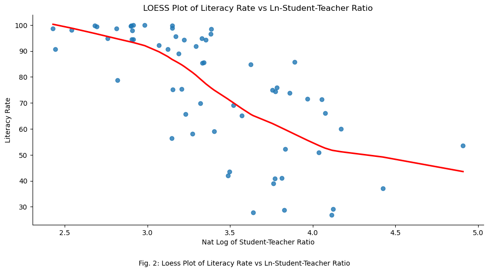

### Appendix 5

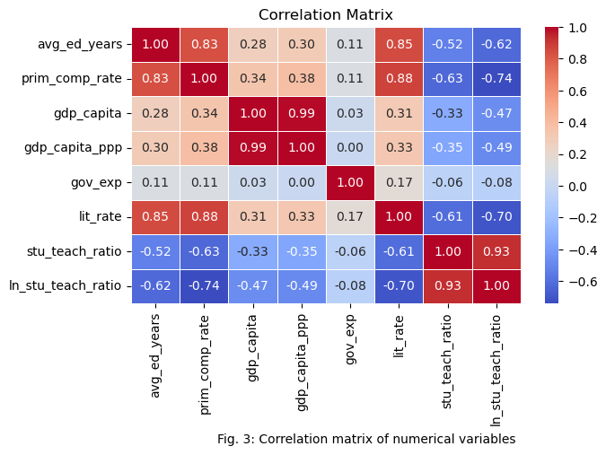

### Appendix 6

OLS Regression Results

| Dep. Variable: | lit_rate | R-squared: | 0.822 |
| --- | --- | --- | --- |
| Model: | OLS | Adj. R-squared: | 0.809 |
| Method: | Least Squares | F-statistic: | 59.92 |
| Date: | Fri, 22 Dec 2023 | Prob (F-statistic): | 1.38e-19 |
| Time: | 20:47:47 | Log-Likelihood: | -224.36 |
| No. Observations: | 61 | AIC: | 458.7 |
| Df Residuals: | 56 | BIC: | 469.3 |
| Df Model: | 4 |  |  |
| Covariance Type: | HC1 |  |  |

|  | coef | std err | z | P>\|z\| | [0.025 | 0.975] |
| --- | --- | --- | --- | --- | --- | --- |
| Intercept | 32.4426 | 11.106 | 2.921 | 0.003 | 10.676 | 54.209 |
| ln_stu_teach_ratio | -4.9310 | 2.334 | -2.113 | 0.035 | -9.506 | -0.356 |
| gov_exp | 0.9219 | 0.678 | 1.360 | 0.174 | -0.407 | 2.251 |
| prim_comp_rate | 0.4896 | 0.115 | 4.257 | 0.000 | 0.264 | 0.715 |
| avg_ed_years | 3.0244 | 0.875 | 3.456 | 0.001 | 1.309 | 4.739 |

| Omnibus: | 0.294 | Durbin-Watson: | 2.079 |
| --- | --- | --- | --- |
| Prob(Omnibus): | 0.863 | Jarque-Bera (JB): | 0.051 |
| Skew: | -0.065 | Prob(JB): | 0.975 |
| Kurtosis: | 3.058 | Cond. No. | 1.18e+03 |

Notes:  
[1] Standard Errors are heteroscedasticity robust (HC1)  
[2] The condition number is large, 1.18e+03. This might indicate that there are  
strong multicollinearity or other numerical problems.